# HW 02 - Counting jelly beans

Individual assignment

Due: Sep 17 at 23:59

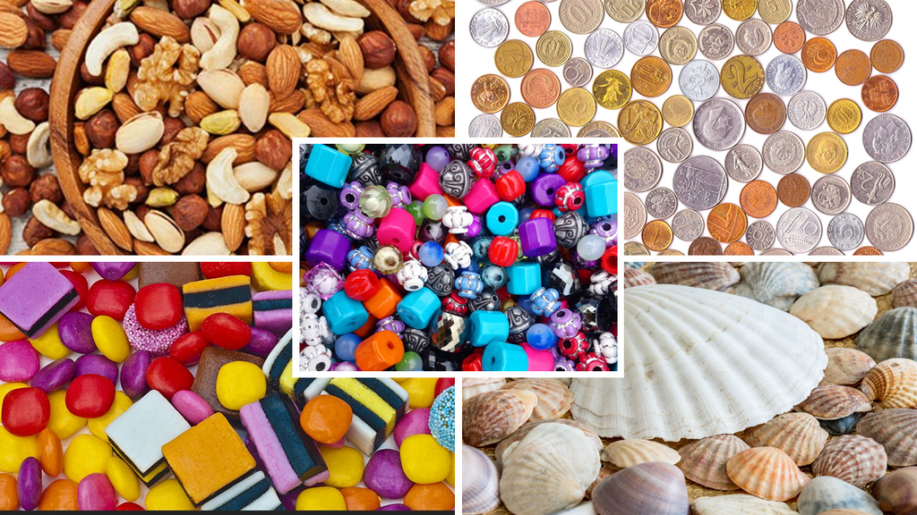

# Introduction

The main goal of this assignment is to collect YOUR OWN data, sample it many times. At the end of the lab, you will discover:

- How can you influence the sampling distribution?
- Why you would want to do so?

# Getting started

If you have technical difficulties with your R and RStudio, please use the University’s [remote desktop](https://uwp.rug.nl/) to run RStudio. If you are working on your own desktop, make sure you download your R and RStudio and make a copy of the project for this assignment: `hw-02-solution.Rmd`

You may need to load the following libraries: Make sure they are loaded in the first code-chunk. If you need additional libraries, please load them there, too.

```r
library(tidyverse)
library(knitr)
library(kableExtra)
```

As usual, make sure that you install all the libraries you need in the console of RStudio. Please do *not* install any packages in your RMarkdown file. However, you will need to load the required packages using the `library(<package name>)` command.